# Conversion Rate

## Goal

Optimizing conversion rate is likely the most common work of a data scientist, and rightfully so. The data revolution has a lot to do with the fact that now we are able to collect all sorts of data about people who buy something on our site as well as people who don't. This gives us a tremendous opportunity to understand what's working well (and potentially scale it even further) and what's not working well (and ﬁx it). The goal of this challenge is to build a model that predicts conversion rate and, based on the model, come up with ideas to improve revenue.

## Challenge Description

We have data about users who hit our site: whether they converted or not as well as some of their characteristics such as their country, the marketing channel, their age, whether they are repeat users and the number of pages visited during that session (as a proxy for site activity/time spent on site). Your project is to:

- Predict conversion rate
- Come up with recommendations for the product team and the marketing team to improve conversion rate

### Columns

- country : user country based on the IP address
- age : user age. Self-reported at sign-in step
- new_user : whether the user created the account during this session or had already an account and simply came back to the site
- source : marketing channel source
  - Ads: came to the site by clicking on an advertisement
  - Seo: came to the site by clicking on search results
  - Direct: came to the site by directly typing the URL on the browser
- total_pages_visited: number of total pages visited during the session. This is a proxy for time spent on site and engagement during the session.
- converted: this is our label.
  - 1 means they converted within the session,
  - 0 means they left without buying anything.

**The company goal is to increase conversion rate: conversions / total sessions.**

```python
import pandas as pd
import numpy as np
import warnings
warnings.filterwarnings("ignore")
```

# Import and EDA

- import data
- check null
- check num columns & num of rows
- check colnames
- check response variable
- value_counts for all other variable

```python
df = pd.read_csv('conversion_data.csv')
df.head(3)
```

|  | country | age | new_user | source | total_pages_visited | converted |
| --- | --- | --- | --- | --- | --- | --- |
| 0 | UK | 25 | 1 | Ads | 1 | 0 |
| 1 | US | 23 | 1 | Seo | 5 | 0 |
| 2 | US | 28 | 1 | Seo | 4 | 0 |

```python
df.info()
df.columns
#df.converted
```

```
<class 'pandas.core.frame.DataFrame'>
RangeIndex: 316200 entries, 0 to 316199
Data columns (total 6 columns):
 #   Column               Non-Null Count   Dtype
---  ------               --------------   -----
 0   country              316200 non-null  object
 1   age                  316200 non-null  int64
 2   new_user             316200 non-null  int64
 3   source               316200 non-null  object
 4   total_pages_visited  316200 non-null  int64
 5   converted            316200 non-null  int64
dtypes: int64(4), object(2)
memory usage: 14.5+ MB
```

```
Index(['country', 'age', 'new_user', 'source', 'total_pages_visited',
       'converted'],
      dtype='object')
```

```python
df.country.value_counts()
#df.age.value_counts()
#df.new_user.value_counts()
#df.source.value_counts()
#df.total_pages_visited.value_counts()
```

```
US         178092
China       76602
UK          48450
Germany     13056
Name: country, dtype: int64
```

### Encode categorical variable

- Try pd.get_dummy() first (This is called *label encoding*)
- Try one hot encoding later (Optional)

```python
df.converted = pd.get_dummies(df.converted,drop_first=True)
```

### check outlier for numerical variable (Optional)

- box plot
- 3 standard deviation method

```python
import seaborn as sns
import matplotlib.pyplot as plt
%matplotlib inline

#plt.figure(figsize=(10,7))
#sns.boxplot(x='converted',y='total_pages_visited',data=df)
```

### Other feature engineering, like incorporate more features (Optional)

- age bin
- total page bin

```python
rate
```

```
[0.5632258064516129,
 0.24225806451612902,
 0.1532258064516129,
 0.04129032258064516]
```

[figure not shown]

```python
sns.countplot(x='age',data=df)
```

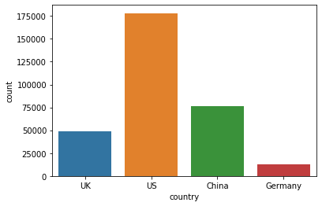

```python
'''fig, ax = plt.barplots(nrows=2, figsize=(12,8))

lst = [178092,76602,48450,13056]
county = ['US','China','UK','Germenay']
# Plot the distribution
sns.barplot(x=county,y=lst, ax=ax[0], color='r')
'''
sns.countplot(x='country',data=df)
```

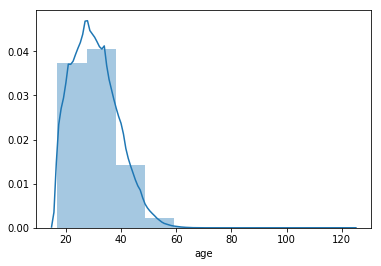

```python
sns.distplot(df['age'],bins=10)
```

```python
'''
def bin(x):
        if x <= 20:
            return 1
        elif x >20 and x<=40:
            return 2
        elif x >40 and x <= 60:
            return 3
        else:
            return 4

#df.age = df.age.apply(bin)

#df.age.value_counts()
'''
```

[output not shown]

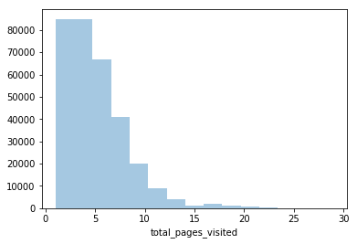

```python
sns.distplot(df['total_pages_visited'], kde=False,bins=15)
```

```python
'''

def binbin(x):
        if x <= 5:
            return 1
        elif x >5 and x<=10:
            return 2
        elif x >10 and x <= 15:
            return 3
        else:
            return 4

#df['total_pages_visited'] = df['total_pages_visited'].apply(binbin)

#df['total_pages_visited'].value_counts()
'''
```

[output not shown]

```python
def jas(x):
    if x == 'Seo':
        return 1
    elif x=='Ads':
        return 2
    else:
        return 3

df.source = df.source.apply(jas)
```

```python
def country(x):
    if x == 'US':
        return 1
    elif x=='China':
        return 2
    elif x=='UK':
        return 3
    else:
        return 4

df.country = df.country.apply(country)
```

```python
df.converted.value_counts()
```

```
0    306000
1     10200
Name: converted, dtype: int64
```

```python
df
```

|  | country | age | new_user | source | total_pages_visited | converted |
| --- | --- | --- | --- | --- | --- | --- |
| 0 | 3 | 25 | 1 | 2 | 1 | 0 |
| 1 | 1 | 23 | 1 | 1 | 5 | 0 |
| 2 | 1 | 28 | 1 | 1 | 4 | 0 |
| 3 | 2 | 39 | 1 | 1 | 5 | 0 |
| 4 | 1 | 30 | 1 | 1 | 6 | 0 |
| ... | ... | ... | ... | ... | ... | ... |
| 316195 | 1 | 26 | 1 | 2 | 9 | 0 |
| 316196 | 1 | 27 | 1 | 3 | 6 | 0 |
| 316197 | 2 | 25 | 0 | 2 | 4 | 0 |
| 316198 | 1 | 22 | 0 | 1 | 4 | 0 |
| 316199 | 3 | 24 | 0 | 2 | 4 | 0 |

316200 rows × 6 columns

# Train-validation-test split

### split your data in 70/30 train/test, validation set is built while you are fitting models

```python
from sklearn.model_selection import train_test_split
```

```python
X = df[['country','age','new_user','source','total_pages_visited']]
y=df['converted']
```

```python
X_train, X_test, y_train, y_test = train_test_split(X, y, test_size=0.3, random_state=101)
```

```python
train_df=pd.concat([X_train,y_train],axis=1)
test_df=pd.concat([X_test,y_test],axis=1)
```

```python
train_df
```

|  | country | age | new_user | source | total_pages_visited | converted |
| --- | --- | --- | --- | --- | --- | --- |
| 173253 | 1 | 28 | 1 | 2 | 6 | 0 |
| 166776 | 1 | 29 | 0 | 2 | 2 | 0 |
| 29417 | 1 | 35 | 0 | 1 | 4 | 0 |
| 273142 | 1 | 25 | 0 | 1 | 1 | 0 |
| 19929 | 3 | 24 | 0 | 2 | 3 | 0 |
| 192081 | 1 | 19 | 1 | 1 | 5 | 0 |
| 199197 | 1 | 19 | 0 | 2 | 4 | 0 |
| 274097 | 1 | 19 | 1 | 3 | 4 | 0 |
| 19357 | 3 | 45 | 1 | 1 | 1 | 0 |
| 166979 | 1 | 37 | 0 | 1 | 3 | 0 |
| 36389 | 1 | 27 | 1 | 1 | 8 | 0 |
| 145656 | 2 | 26 | 1 | 3 | 9 | 0 |
| 257938 | 1 | 28 | 1 | 1 | 1 | 0 |
| 60434 | 2 | 25 | 1 | 3 | 4 | 0 |
| 293169 | 3 | 35 | 1 | 1 | 3 | 0 |
| 76006 | 3 | 27 | 0 | 2 | 5 | 0 |
| 282789 | 3 | 31 | 1 | 1 | 4 | 0 |
| 228202 | 1 | 35 | 1 | 3 | 6 | 0 |
| 98687 | 3 | 37 | 0 | 1 | 8 | 0 |
| 43381 | 1 | 47 | 1 | 1 | 3 | 0 |
| 236281 | 3 | 22 | 1 | 1 | 6 | 0 |
| 307681 | 2 | 32 | 1 | 2 | 3 | 0 |
| 68206 | 1 | 31 | 0 | 3 | 1 | 0 |
| 108299 | 1 | 39 | 1 | 3 | 3 | 0 |
| 108560 | 1 | 38 | 1 | 3 | 2 | 0 |
| 46035 | 3 | 26 | 1 | 1 | 7 | 0 |
| 63672 | 1 | 18 | 1 | 1 | 4 | 0 |
| 250530 | 4 | 24 | 1 | 2 | 7 | 0 |
| 312289 | 1 | 20 | 0 | 3 | 1 | 0 |
| 152050 | 3 | 33 | 1 | 1 | 7 | 0 |
| ... | ... | ... | ... | ... | ... | ... |
| 152531 | 2 | 36 | 0 | 3 | 8 | 0 |
| 237118 | 3 | 31 | 1 | 1 | 6 | 0 |
| 77257 | 1 | 42 | 1 | 2 | 6 | 0 |
| 222711 | 2 | 30 | 1 | 1 | 4 | 0 |
| 97152 | 2 | 39 | 1 | 3 | 2 | 0 |
| 194155 | 1 | 29 | 0 | 1 | 3 | 0 |
| 151263 | 2 | 19 | 1 | 3 | 1 | 0 |
| 15436 | 4 | 32 | 1 | 1 | 9 | 0 |
| 117011 | 3 | 36 | 1 | 3 | 2 | 0 |
| 28488 | 2 | 35 | 0 | 3 | 7 | 0 |
| 140844 | 1 | 34 | 1 | 1 | 11 | 0 |
| 251298 | 2 | 25 | 1 | 2 | 1 | 0 |
| 280635 | 2 | 17 | 1 | 3 | 4 | 0 |
| 231325 | 2 | 36 | 0 | 2 | 6 | 0 |
| 315763 | 3 | 33 | 1 | 3 | 8 | 0 |
| 125064 | 1 | 20 | 0 | 2 | 1 | 0 |
| 91642 | 3 | 29 | 1 | 2 | 5 | 0 |
| 32817 | 1 | 34 | 0 | 1 | 3 | 0 |
| 121861 | 2 | 23 | 0 | 1 | 4 | 0 |
| 250792 | 1 | 41 | 1 | 3 | 2 | 0 |
| 35391 | 1 | 27 | 1 | 3 | 2 | 0 |
| 153128 | 1 | 44 | 1 | 1 | 2 | 0 |
| 148429 | 1 | 48 | 0 | 1 | 6 | 0 |
| 228745 | 2 | 27 | 1 | 1 | 4 | 0 |
| 55293 | 1 | 38 | 1 | 3 | 2 | 0 |
| 311895 | 1 | 21 | 1 | 3 | 2 | 0 |
| 136767 | 1 | 45 | 1 | 1 | 2 | 0 |
| 204614 | 3 | 36 | 1 | 3 | 4 | 0 |
| 214539 | 1 | 31 | 0 | 1 | 5 | 0 |
| 176991 | 1 | 34 | 1 | 1 | 2 | 0 |

221340 rows × 6 columns

```python
sample = train_df[train_df.converted ==0]
sample1=train_df[train_df.converted ==1]
```

```python
new=sample.sample(n=7211)
new.head(3)
newdf=pd.concat(objs=[new,sample1]).reset_index()
newdf.head(3)
len(newdf)
df2 = newdf.sample(frac=1)
df2.drop('index',axis=1,inplace=True)
```

```python
df2.columns
```

```
Index(['country', 'age', 'new_user', 'source', 'total_pages_visited',
       'converted'],
      dtype='object')
```

```python
X_train=df2[df2.columns[:5]]
```

```python
y_train=df2.converted
```

# Model building

- **Use 5 fold validation method and take average metric for each method**
- **Choose the appropriate metrics while fitting models, egs: roc_auc, recall, accuracy, precision, f_score, etc**

### 1. Logistic regression model

### 2. Classification Tree model

### 3. random forest

### 4. gradient boosting tree

```python
from sklearn import metrics
from statistics import mean
```

```python
from sklearn.metrics import classification_report,confusion_matrix
from sklearn.model_selection import cross_val_score
from sklearn.metrics import roc_auc_score
```

```python
# logistic
from sklearn.linear_model import LogisticRegression

log = LogisticRegression()
# validation
kmean_lr = mean(cross_val_score(log,X_train,y_train,cv=5,scoring='accuracy'))
print(kmean_lr)
# test
log.fit(X_train,y_train)
pred = log.predict(X_test)
print('Test report')
print(classification_report(y_test,pred),confusion_matrix(y_test,pred))
```

```
0.934475153659586
Test report
              precision    recall  f1-score   support

           0       1.00      0.94      0.97     91871
           1       0.32      0.93      0.48      2989

    accuracy                           0.94     94860
   macro avg       0.66      0.93      0.72     94860
weighted avg       0.98      0.94      0.95     94860
 [[85944  5927]
 [  201  2788]]
```

```python
# tree
from sklearn.tree import DecisionTreeClassifier

tree=DecisionTreeClassifier()
# validation
kmean_tree = mean(cross_val_score(tree,X_train,y_train,cv=5,scoring='accuracy'))
print(kmean_tree)

# test
tree.fit(X_train,y_train)
pred = tree.predict(X_test)
print('test report')
print(classification_report(y_test,pred),confusion_matrix(y_test,pred))
```

```
0.9157537312177146
test report
              precision    recall  f1-score   support

           0       1.00      0.93      0.96     91871
           1       0.30      0.91      0.46      2989

    accuracy                           0.93     94860
   macro avg       0.65      0.92      0.71     94860
weighted avg       0.97      0.93      0.95     94860
 [[85693  6178]
 [  282  2707]]
```

```python
# rf
from sklearn.ensemble import RandomForestClassifier

rf=RandomForestClassifier(n_estimators=20 ,n_jobs=-1)
# validation
kmean_rf = mean(cross_val_score(rf,X_train,y_train,cv=5,scoring='accuracy'))
print(kmean_rf)
# test
rf.fit(X_train,y_train)
pred = rf.predict(X_test)
print('test report')
print(classification_report(y_test,pred),confusion_matrix(y_test,pred))
```

```
0.9260161483785518
test report
              precision    recall  f1-score   support

           0       1.00      0.93      0.96     91871
           1       0.29      0.93      0.45      2989

    accuracy                           0.93     94860
   macro avg       0.65      0.93      0.70     94860
weighted avg       0.98      0.93      0.94     94860
 [[85159  6712]
 [  202  2787]]
```

```python
# boost
from sklearn.ensemble import GradientBoostingClassifier

boost = GradientBoostingClassifier()
# validation
kmean_boost = mean(cross_val_score(boost,X_train,y_train,cv=5,scoring='accuracy'))
print(kmean_boost)
# test
boost.fit(X_train,y_train)
pred = boost.predict(X_test)
print('test report')
print(classification_report(y_test,pred),confusion_matrix(y_test,pred))
print(roc_auc_score(y_test,pred))
```

```
0.9421721468113082
test report
              precision    recall  f1-score   support

           0       1.00      0.94      0.97     91871
           1       0.33      0.94      0.49      2989

    accuracy                           0.94     94860
   macro avg       0.66      0.94      0.73     94860
weighted avg       0.98      0.94      0.95     94860
 [[86150  5721]
 [  177  2812]]
0.939255385801973
```

```python
pd.Series(pred).value_counts()
```

```
0    86767
1     8093
dtype: int64
```

# Model tunning

- Tune your best validation model
- Try to tune logistic regression model

```python
kmeans = [kmean_lr,kmean_tree,kmean_rf,kmean_boost]
print(max(kmeans))
```

[output not shown]

```python
name_list=['logitstic regression','tree','rf','boost']
decision=dict(zip(name_list,kmeans))
decision
```

[output not shown]

looks like gradient boosting has the highest cross val score in accurcay

# Model Report

- feature importance rate

[figure not shown]

```python
feature_importance = boost.feature_importances_
sorted_idx = np.argsort(feature_importance)
pos = np.arange(sorted_idx.shape[0]) + .5
fig = plt.figure(figsize=(12, 6))
plt.subplot(1, 2, 1)
plt.barh(pos, feature_importance[sorted_idx], align='center')
plt.yticks(pos, np.array(X_train.columns)[sorted_idx])
plt.title('Feature Importance')

plt.show()
```

```python
# conversion rate
8093/(86767+8093)
```

```
0.08531520134935695
```

## start from the original df, use one hot encoding to do more analysis

- age bin
- page_bin

use numpy.quantile to check 0.25,0.5,0.75 percentile

```python
df
```

|  | country | age | new_user | source | total_pages_visited | converted |
| --- | --- | --- | --- | --- | --- | --- |
| 0 | UK | 25 | 1 | Ads | 1 | 0 |
| 1 | US | 23 | 1 | Seo | 5 | 0 |
| 2 | US | 28 | 1 | Seo | 4 | 0 |
| 3 | China | 39 | 1 | Seo | 5 | 0 |
| 4 | US | 30 | 1 | Seo | 6 | 0 |
| 5 | US | 31 | 0 | Seo | 1 | 0 |
| 6 | China | 27 | 1 | Seo | 4 | 0 |
| 7 | US | 23 | 0 | Ads | 4 | 0 |
| 8 | UK | 29 | 0 | Direct | 4 | 0 |
| 9 | US | 25 | 0 | Ads | 2 | 0 |
| 10 | US | 38 | 0 | Seo | 1 | 0 |
| 11 | US | 43 | 1 | Direct | 8 | 0 |
| 12 | China | 31 | 0 | Seo | 6 | 0 |
| 13 | UK | 23 | 1 | Direct | 7 | 0 |
| 14 | China | 27 | 1 | Ads | 3 | 0 |
| 15 | US | 24 | 1 | Seo | 4 | 0 |
| 16 | US | 39 | 0 | Seo | 3 | 0 |
| 17 | China | 36 | 0 | Direct | 9 | 0 |
| 18 | China | 37 | 0 | Ads | 6 | 0 |
| 19 | US | 27 | 1 | Ads | 7 | 0 |
| 20 | US | 33 | 1 | Ads | 9 | 0 |
| 21 | UK | 20 | 1 | Ads | 1 | 0 |
| 22 | UK | 27 | 0 | Direct | 4 | 0 |
| 23 | US | 37 | 1 | Direct | 6 | 0 |
| 24 | China | 25 | 0 | Seo | 3 | 0 |
| 25 | US | 35 | 1 | Seo | 14 | 0 |
| 26 | US | 24 | 1 | Seo | 3 | 0 |
| 27 | China | 39 | 1 | Direct | 7 | 0 |
| 28 | Germany | 17 | 0 | Seo | 1 | 0 |
| 29 | US | 36 | 1 | Direct | 10 | 0 |
| ... | ... | ... | ... | ... | ... | ... |
| 316170 | US | 33 | 1 | Seo | 5 | 0 |
| 316171 | US | 36 | 0 | Seo | 1 | 0 |
| 316172 | US | 28 | 1 | Ads | 1 | 0 |
| 316173 | UK | 24 | 1 | Ads | 2 | 0 |
| 316174 | China | 41 | 0 | Seo | 5 | 0 |
| 316175 | UK | 21 | 0 | Ads | 2 | 0 |
| 316176 | US | 22 | 1 | Seo | 5 | 0 |
| 316177 | UK | 24 | 1 | Seo | 1 | 0 |
| 316178 | UK | 25 | 1 | Seo | 11 | 0 |
| 316179 | UK | 20 | 1 | Seo | 4 | 0 |
| 316180 | US | 23 | 1 | Seo | 3 | 0 |
| 316181 | US | 28 | 0 | Seo | 8 | 0 |
| 316182 | US | 24 | 1 | Ads | 3 | 0 |
| 316183 | US | 39 | 1 | Seo | 6 | 0 |
| 316184 | UK | 26 | 1 | Seo | 16 | 1 |
| 316185 | China | 27 | 1 | Direct | 7 | 0 |
| 316186 | China | 23 | 1 | Direct | 7 | 0 |
| 316187 | China | 30 | 1 | Seo | 2 | 0 |
| 316188 | US | 44 | 0 | Seo | 4 | 0 |
| 316189 | China | 17 | 0 | Ads | 6 | 0 |
| 316190 | US | 23 | 0 | Ads | 4 | 0 |
| 316191 | US | 40 | 0 | Seo | 4 | 0 |
| 316192 | China | 35 | 1 | Seo | 7 | 0 |
| 316193 | UK | 32 | 1 | Direct | 5 | 0 |
| 316194 | UK | 28 | 0 | Seo | 8 | 0 |
| 316195 | US | 26 | 1 | Ads | 9 | 0 |
| 316196 | US | 27 | 1 | Direct | 6 | 0 |
| 316197 | China | 25 | 0 | Ads | 4 | 0 |
| 316198 | US | 22 | 0 | Seo | 4 | 0 |
| 316199 | UK | 24 | 0 | Ads | 4 | 0 |

316200 rows × 6 columns

```python
np.quantile(df.age,0.25)
```

```
24.0
```

```python
np.quantile(df.age,0.5)
```

```
30.0
```

```python
np.quantile(df.age,0.75)
```

```
36.0
```

```python
countries = pd.get_dummies(df.country)
countries
```

|  | China | Germany | UK | US |
| --- | --- | --- | --- | --- |
| 0 | 0 | 0 | 1 | 0 |
| 1 | 0 | 0 | 0 | 1 |
| 2 | 0 | 0 | 0 | 1 |
| 3 | 1 | 0 | 0 | 0 |
| 4 | 0 | 0 | 0 | 1 |
| 5 | 0 | 0 | 0 | 1 |
| 6 | 1 | 0 | 0 | 0 |
| 7 | 0 | 0 | 0 | 1 |
| 8 | 0 | 0 | 1 | 0 |
| 9 | 0 | 0 | 0 | 1 |
| 10 | 0 | 0 | 0 | 1 |
| 11 | 0 | 0 | 0 | 1 |
| 12 | 1 | 0 | 0 | 0 |
| 13 | 0 | 0 | 1 | 0 |
| 14 | 1 | 0 | 0 | 0 |
| 15 | 0 | 0 | 0 | 1 |
| 16 | 0 | 0 | 0 | 1 |
| 17 | 1 | 0 | 0 | 0 |
| 18 | 1 | 0 | 0 | 0 |
| 19 | 0 | 0 | 0 | 1 |
| 20 | 0 | 0 | 0 | 1 |
| 21 | 0 | 0 | 1 | 0 |
| 22 | 0 | 0 | 1 | 0 |
| 23 | 0 | 0 | 0 | 1 |
| 24 | 1 | 0 | 0 | 0 |
| 25 | 0 | 0 | 0 | 1 |
| 26 | 0 | 0 | 0 | 1 |
| 27 | 1 | 0 | 0 | 0 |
| 28 | 0 | 1 | 0 | 0 |
| 29 | 0 | 0 | 0 | 1 |
| ... | ... | ... | ... | ... |
| 316170 | 0 | 0 | 0 | 1 |
| 316171 | 0 | 0 | 0 | 1 |
| 316172 | 0 | 0 | 0 | 1 |
| 316173 | 0 | 0 | 1 | 0 |
| 316174 | 1 | 0 | 0 | 0 |
| 316175 | 0 | 0 | 1 | 0 |
| 316176 | 0 | 0 | 0 | 1 |
| 316177 | 0 | 0 | 1 | 0 |
| 316178 | 0 | 0 | 1 | 0 |
| 316179 | 0 | 0 | 1 | 0 |
| 316180 | 0 | 0 | 0 | 1 |
| 316181 | 0 | 0 | 0 | 1 |
| 316182 | 0 | 0 | 0 | 1 |
| 316183 | 0 | 0 | 0 | 1 |
| 316184 | 0 | 0 | 1 | 0 |
| 316185 | 1 | 0 | 0 | 0 |
| 316186 | 1 | 0 | 0 | 0 |
| 316187 | 1 | 0 | 0 | 0 |
| 316188 | 0 | 0 | 0 | 1 |
| 316189 | 1 | 0 | 0 | 0 |
| 316190 | 0 | 0 | 0 | 1 |
| 316191 | 0 | 0 | 0 | 1 |
| 316192 | 1 | 0 | 0 | 0 |
| 316193 | 0 | 0 | 1 | 0 |
| 316194 | 0 | 0 | 1 | 0 |
| 316195 | 0 | 0 | 0 | 1 |
| 316196 | 0 | 0 | 0 | 1 |
| 316197 | 1 | 0 | 0 | 0 |
| 316198 | 0 | 0 | 0 | 1 |
| 316199 | 0 | 0 | 1 | 0 |

316200 rows × 4 columns

```python
sources = pd.get_dummies(df.source)
sources
```

|  | Ads | Direct | Seo |
| --- | --- | --- | --- |
| 0 | 1 | 0 | 0 |
| 1 | 0 | 0 | 1 |
| 2 | 0 | 0 | 1 |
| 3 | 0 | 0 | 1 |
| 4 | 0 | 0 | 1 |
| 5 | 0 | 0 | 1 |
| 6 | 0 | 0 | 1 |
| 7 | 1 | 0 | 0 |
| 8 | 0 | 1 | 0 |
| 9 | 1 | 0 | 0 |
| 10 | 0 | 0 | 1 |
| 11 | 0 | 1 | 0 |
| 12 | 0 | 0 | 1 |
| 13 | 0 | 1 | 0 |
| 14 | 1 | 0 | 0 |
| 15 | 0 | 0 | 1 |
| 16 | 0 | 0 | 1 |
| 17 | 0 | 1 | 0 |
| 18 | 1 | 0 | 0 |
| 19 | 1 | 0 | 0 |
| 20 | 1 | 0 | 0 |
| 21 | 1 | 0 | 0 |
| 22 | 0 | 1 | 0 |
| 23 | 0 | 1 | 0 |
| 24 | 0 | 0 | 1 |
| 25 | 0 | 0 | 1 |
| 26 | 0 | 0 | 1 |
| 27 | 0 | 1 | 0 |
| 28 | 0 | 0 | 1 |
| 29 | 0 | 1 | 0 |
| ... | ... | ... | ... |
| 316170 | 0 | 0 | 1 |
| 316171 | 0 | 0 | 1 |
| 316172 | 1 | 0 | 0 |
| 316173 | 1 | 0 | 0 |
| 316174 | 0 | 0 | 1 |
| 316175 | 1 | 0 | 0 |
| 316176 | 0 | 0 | 1 |
| 316177 | 0 | 0 | 1 |
| 316178 | 0 | 0 | 1 |
| 316179 | 0 | 0 | 1 |
| 316180 | 0 | 0 | 1 |
| 316181 | 0 | 0 | 1 |
| 316182 | 1 | 0 | 0 |
| 316183 | 0 | 0 | 1 |
| 316184 | 0 | 0 | 1 |
| 316185 | 0 | 1 | 0 |
| 316186 | 0 | 1 | 0 |
| 316187 | 0 | 0 | 1 |
| 316188 | 0 | 0 | 1 |
| 316189 | 1 | 0 | 0 |
| 316190 | 1 | 0 | 0 |
| 316191 | 0 | 0 | 1 |
| 316192 | 0 | 0 | 1 |
| 316193 | 0 | 1 | 0 |
| 316194 | 0 | 0 | 1 |
| 316195 | 1 | 0 | 0 |
| 316196 | 0 | 1 | 0 |
| 316197 | 1 | 0 | 0 |
| 316198 | 0 | 0 | 1 |
| 316199 | 1 | 0 | 0 |

316200 rows × 3 columns

```python
def bin(x):
        if x <= 24:
            return 'teen'
        elif x >24 and x<=30:
            return 'adult'
        elif x >30 and x <= 36:
            return 'old adult'
        else:
            return 'old'

df.age = df.age.apply(bin)

ages = pd.get_dummies(df.age)
ages
```

|  | adult | old | old adult | teen |
| --- | --- | --- | --- | --- |
| 0 | 1 | 0 | 0 | 0 |
| 1 | 0 | 0 | 0 | 1 |
| 2 | 1 | 0 | 0 | 0 |
| 3 | 0 | 1 | 0 | 0 |
| 4 | 1 | 0 | 0 | 0 |
| 5 | 0 | 0 | 1 | 0 |
| 6 | 1 | 0 | 0 | 0 |
| 7 | 0 | 0 | 0 | 1 |
| 8 | 1 | 0 | 0 | 0 |
| 9 | 1 | 0 | 0 | 0 |
| 10 | 0 | 1 | 0 | 0 |
| 11 | 0 | 1 | 0 | 0 |
| 12 | 0 | 0 | 1 | 0 |
| 13 | 0 | 0 | 0 | 1 |
| 14 | 1 | 0 | 0 | 0 |
| 15 | 0 | 0 | 0 | 1 |
| 16 | 0 | 1 | 0 | 0 |
| 17 | 0 | 0 | 1 | 0 |
| 18 | 0 | 1 | 0 | 0 |
| 19 | 1 | 0 | 0 | 0 |
| 20 | 0 | 0 | 1 | 0 |
| 21 | 0 | 0 | 0 | 1 |
| 22 | 1 | 0 | 0 | 0 |
| 23 | 0 | 1 | 0 | 0 |
| 24 | 1 | 0 | 0 | 0 |
| 25 | 0 | 0 | 1 | 0 |
| 26 | 0 | 0 | 0 | 1 |
| 27 | 0 | 1 | 0 | 0 |
| 28 | 0 | 0 | 0 | 1 |
| 29 | 0 | 0 | 1 | 0 |
| ... | ... | ... | ... | ... |
| 316170 | 0 | 0 | 1 | 0 |
| 316171 | 0 | 0 | 1 | 0 |
| 316172 | 1 | 0 | 0 | 0 |
| 316173 | 0 | 0 | 0 | 1 |
| 316174 | 0 | 1 | 0 | 0 |
| 316175 | 0 | 0 | 0 | 1 |
| 316176 | 0 | 0 | 0 | 1 |
| 316177 | 0 | 0 | 0 | 1 |
| 316178 | 1 | 0 | 0 | 0 |
| 316179 | 0 | 0 | 0 | 1 |
| 316180 | 0 | 0 | 0 | 1 |
| 316181 | 1 | 0 | 0 | 0 |
| 316182 | 0 | 0 | 0 | 1 |
| 316183 | 0 | 1 | 0 | 0 |
| 316184 | 1 | 0 | 0 | 0 |
| 316185 | 1 | 0 | 0 | 0 |
| 316186 | 0 | 0 | 0 | 1 |
| 316187 | 1 | 0 | 0 | 0 |
| 316188 | 0 | 1 | 0 | 0 |
| 316189 | 0 | 0 | 0 | 1 |
| 316190 | 0 | 0 | 0 | 1 |
| 316191 | 0 | 1 | 0 | 0 |
| 316192 | 0 | 0 | 1 | 0 |
| 316193 | 0 | 0 | 1 | 0 |
| 316194 | 1 | 0 | 0 | 0 |
| 316195 | 1 | 0 | 0 | 0 |
| 316196 | 1 | 0 | 0 | 0 |
| 316197 | 1 | 0 | 0 | 0 |
| 316198 | 0 | 0 | 0 | 1 |
| 316199 | 0 | 0 | 0 | 1 |

316200 rows × 4 columns

```python
np.quantile(df['total_pages_visited'],0.25)
```

```
2.0
```

```python
np.quantile(df['total_pages_visited'],0.5)
```

```
4.0
```

```python
np.quantile(df['total_pages_visited'],0.75)
```

```
7.0
```

```python
def binbin(x):
        if x <= 2:
            return 'none'
        elif x >2 and x<=4:
            return 'barely'
        elif x >4 and x <= 7:
            return 'some'
        else:
            return 'more'

df['total_pages_visited'] = df['total_pages_visited'].apply(binbin)

#df['total_pages_visited'].value_counts()

pages = pd.get_dummies(df['total_pages_visited'])
pages
```

|  | barely | more | none | some |
| --- | --- | --- | --- | --- |
| 0 | 0 | 0 | 1 | 0 |
| 1 | 0 | 0 | 0 | 1 |
| 2 | 1 | 0 | 0 | 0 |
| 3 | 0 | 0 | 0 | 1 |
| 4 | 0 | 0 | 0 | 1 |
| 5 | 0 | 0 | 1 | 0 |
| 6 | 1 | 0 | 0 | 0 |
| 7 | 1 | 0 | 0 | 0 |
| 8 | 1 | 0 | 0 | 0 |
| 9 | 0 | 0 | 1 | 0 |
| 10 | 0 | 0 | 1 | 0 |
| 11 | 0 | 1 | 0 | 0 |
| 12 | 0 | 0 | 0 | 1 |
| 13 | 0 | 0 | 0 | 1 |
| 14 | 1 | 0 | 0 | 0 |
| 15 | 1 | 0 | 0 | 0 |
| 16 | 1 | 0 | 0 | 0 |
| 17 | 0 | 1 | 0 | 0 |
| 18 | 0 | 0 | 0 | 1 |
| 19 | 0 | 0 | 0 | 1 |
| 20 | 0 | 1 | 0 | 0 |
| 21 | 0 | 0 | 1 | 0 |
| 22 | 1 | 0 | 0 | 0 |
| 23 | 0 | 0 | 0 | 1 |
| 24 | 1 | 0 | 0 | 0 |
| 25 | 0 | 1 | 0 | 0 |
| 26 | 1 | 0 | 0 | 0 |
| 27 | 0 | 0 | 0 | 1 |
| 28 | 0 | 0 | 1 | 0 |
| 29 | 0 | 1 | 0 | 0 |
| ... | ... | ... | ... | ... |
| 316170 | 0 | 0 | 0 | 1 |
| 316171 | 0 | 0 | 1 | 0 |
| 316172 | 0 | 0 | 1 | 0 |
| 316173 | 0 | 0 | 1 | 0 |
| 316174 | 0 | 0 | 0 | 1 |
| 316175 | 0 | 0 | 1 | 0 |
| 316176 | 0 | 0 | 0 | 1 |
| 316177 | 0 | 0 | 1 | 0 |
| 316178 | 0 | 1 | 0 | 0 |
| 316179 | 1 | 0 | 0 | 0 |
| 316180 | 1 | 0 | 0 | 0 |
| 316181 | 0 | 1 | 0 | 0 |
| 316182 | 1 | 0 | 0 | 0 |
| 316183 | 0 | 0 | 0 | 1 |
| 316184 | 0 | 1 | 0 | 0 |
| 316185 | 0 | 0 | 0 | 1 |
| 316186 | 0 | 0 | 0 | 1 |
| 316187 | 0 | 0 | 1 | 0 |
| 316188 | 1 | 0 | 0 | 0 |
| 316189 | 0 | 0 | 0 | 1 |
| 316190 | 1 | 0 | 0 | 0 |
| 316191 | 1 | 0 | 0 | 0 |
| 316192 | 0 | 0 | 0 | 1 |
| 316193 | 0 | 0 | 0 | 1 |
| 316194 | 0 | 1 | 0 | 0 |
| 316195 | 0 | 1 | 0 | 0 |
| 316196 | 0 | 0 | 0 | 1 |
| 316197 | 1 | 0 | 0 | 0 |
| 316198 | 1 | 0 | 0 | 0 |
| 316199 | 1 | 0 | 0 | 0 |

316200 rows × 4 columns

```python
new_df=pd.concat([df,countries,sources,ages,pages],axis=1)
new_df
new_df.drop(['country','age','source','total_pages_visited'],axis=1,inplace=True)
new_df.head()
```

|  | new_user | converted | China | Germany | UK | US | Ads | Direct | Seo | adult | old | old adult | teen | barely | more | none | some |
| --- | --- | --- | --- | --- | --- | --- | --- | --- | --- | --- | --- | --- | --- | --- | --- | --- | --- |
| 0 | 1 | 0 | 0 | 0 | 1 | 0 | 1 | 0 | 0 | 1 | 0 | 0 | 0 | 0 | 0 | 1 | 0 |
| 1 | 1 | 0 | 0 | 0 | 0 | 1 | 0 | 0 | 1 | 0 | 0 | 0 | 1 | 0 | 0 | 0 | 1 |
| 2 | 1 | 0 | 0 | 0 | 0 | 1 | 0 | 0 | 1 | 1 | 0 | 0 | 0 | 1 | 0 | 0 | 0 |
| 3 | 1 | 0 | 1 | 0 | 0 | 0 | 0 | 0 | 1 | 0 | 1 | 0 | 0 | 0 | 0 | 0 | 1 |
| 4 | 1 | 0 | 0 | 0 | 0 | 1 | 0 | 0 | 1 | 1 | 0 | 0 | 0 | 0 | 0 | 0 | 1 |

```python
X = new_df.drop('converted',axis=1)
y=new_df['converted']
```

```python
X_train, X_test, y_train, y_test = train_test_split(X, y, test_size=0.3, random_state=101)
train_df=pd.concat([X_train,y_train],axis=1)
test_df=pd.concat([X_test,y_test],axis=1)
```

```python
train_df
```

|  | new_user | China | Germany | UK | US | Ads | Direct | Seo | adult | old | old adult | teen | barely | more | none | some | converted |
| --- | --- | --- | --- | --- | --- | --- | --- | --- | --- | --- | --- | --- | --- | --- | --- | --- | --- |
| 173253 | 1 | 0 | 0 | 0 | 1 | 1 | 0 | 0 | 1 | 0 | 0 | 0 | 0 | 0 | 0 | 1 | 0 |
| 166776 | 0 | 0 | 0 | 0 | 1 | 1 | 0 | 0 | 1 | 0 | 0 | 0 | 0 | 0 | 1 | 0 | 0 |
| 29417 | 0 | 0 | 0 | 0 | 1 | 0 | 0 | 1 | 0 | 0 | 1 | 0 | 1 | 0 | 0 | 0 | 0 |
| 273142 | 0 | 0 | 0 | 0 | 1 | 0 | 0 | 1 | 1 | 0 | 0 | 0 | 0 | 0 | 1 | 0 | 0 |
| 19929 | 0 | 0 | 0 | 1 | 0 | 1 | 0 | 0 | 0 | 0 | 0 | 1 | 1 | 0 | 0 | 0 | 0 |
| 192081 | 1 | 0 | 0 | 0 | 1 | 0 | 0 | 1 | 0 | 0 | 0 | 1 | 0 | 0 | 0 | 1 | 0 |
| 199197 | 0 | 0 | 0 | 0 | 1 | 1 | 0 | 0 | 0 | 0 | 0 | 1 | 1 | 0 | 0 | 0 | 0 |
| 274097 | 1 | 0 | 0 | 0 | 1 | 0 | 1 | 0 | 0 | 0 | 0 | 1 | 1 | 0 | 0 | 0 | 0 |
| 19357 | 1 | 0 | 0 | 1 | 0 | 0 | 0 | 1 | 0 | 1 | 0 | 0 | 0 | 0 | 1 | 0 | 0 |
| 166979 | 0 | 0 | 0 | 0 | 1 | 0 | 0 | 1 | 0 | 1 | 0 | 0 | 1 | 0 | 0 | 0 | 0 |
| 36389 | 1 | 0 | 0 | 0 | 1 | 0 | 0 | 1 | 1 | 0 | 0 | 0 | 0 | 1 | 0 | 0 | 0 |
| 145656 | 1 | 1 | 0 | 0 | 0 | 0 | 1 | 0 | 1 | 0 | 0 | 0 | 0 | 1 | 0 | 0 | 0 |
| 257938 | 1 | 0 | 0 | 0 | 1 | 0 | 0 | 1 | 1 | 0 | 0 | 0 | 0 | 0 | 1 | 0 | 0 |
| 60434 | 1 | 1 | 0 | 0 | 0 | 0 | 1 | 0 | 1 | 0 | 0 | 0 | 1 | 0 | 0 | 0 | 0 |
| 293169 | 1 | 0 | 0 | 1 | 0 | 0 | 0 | 1 | 0 | 0 | 1 | 0 | 1 | 0 | 0 | 0 | 0 |
| 76006 | 0 | 0 | 0 | 1 | 0 | 1 | 0 | 0 | 1 | 0 | 0 | 0 | 0 | 0 | 0 | 1 | 0 |
| 282789 | 1 | 0 | 0 | 1 | 0 | 0 | 0 | 1 | 0 | 0 | 1 | 0 | 1 | 0 | 0 | 0 | 0 |
| 228202 | 1 | 0 | 0 | 0 | 1 | 0 | 1 | 0 | 0 | 0 | 1 | 0 | 0 | 0 | 0 | 1 | 0 |
| 98687 | 0 | 0 | 0 | 1 | 0 | 0 | 0 | 1 | 0 | 1 | 0 | 0 | 0 | 1 | 0 | 0 | 0 |
| 43381 | 1 | 0 | 0 | 0 | 1 | 0 | 0 | 1 | 0 | 1 | 0 | 0 | 1 | 0 | 0 | 0 | 0 |
| 236281 | 1 | 0 | 0 | 1 | 0 | 0 | 0 | 1 | 0 | 0 | 0 | 1 | 0 | 0 | 0 | 1 | 0 |
| 307681 | 1 | 1 | 0 | 0 | 0 | 1 | 0 | 0 | 0 | 0 | 1 | 0 | 1 | 0 | 0 | 0 | 0 |
| 68206 | 0 | 0 | 0 | 0 | 1 | 0 | 1 | 0 | 0 | 0 | 1 | 0 | 0 | 0 | 1 | 0 | 0 |
| 108299 | 1 | 0 | 0 | 0 | 1 | 0 | 1 | 0 | 0 | 1 | 0 | 0 | 1 | 0 | 0 | 0 | 0 |
| 108560 | 1 | 0 | 0 | 0 | 1 | 0 | 1 | 0 | 0 | 1 | 0 | 0 | 0 | 0 | 1 | 0 | 0 |
| 46035 | 1 | 0 | 0 | 1 | 0 | 0 | 0 | 1 | 1 | 0 | 0 | 0 | 0 | 0 | 0 | 1 | 0 |
| 63672 | 1 | 0 | 0 | 0 | 1 | 0 | 0 | 1 | 0 | 0 | 0 | 1 | 1 | 0 | 0 | 0 | 0 |
| 250530 | 1 | 0 | 1 | 0 | 0 | 1 | 0 | 0 | 0 | 0 | 0 | 1 | 0 | 0 | 0 | 1 | 0 |
| 312289 | 0 | 0 | 0 | 0 | 1 | 0 | 1 | 0 | 0 | 0 | 0 | 1 | 0 | 0 | 1 | 0 | 0 |
| 152050 | 1 | 0 | 0 | 1 | 0 | 0 | 0 | 1 | 0 | 0 | 1 | 0 | 0 | 0 | 0 | 1 | 0 |
| ... | ... | ... | ... | ... | ... | ... | ... | ... | ... | ... | ... | ... | ... | ... | ... | ... | ... |
| 152531 | 0 | 1 | 0 | 0 | 0 | 0 | 1 | 0 | 0 | 0 | 1 | 0 | 0 | 1 | 0 | 0 | 0 |
| 237118 | 1 | 0 | 0 | 1 | 0 | 0 | 0 | 1 | 0 | 0 | 1 | 0 | 0 | 0 | 0 | 1 | 0 |
| 77257 | 1 | 0 | 0 | 0 | 1 | 1 | 0 | 0 | 0 | 1 | 0 | 0 | 0 | 0 | 0 | 1 | 0 |
| 222711 | 1 | 1 | 0 | 0 | 0 | 0 | 0 | 1 | 1 | 0 | 0 | 0 | 1 | 0 | 0 | 0 | 0 |
| 97152 | 1 | 1 | 0 | 0 | 0 | 0 | 1 | 0 | 0 | 1 | 0 | 0 | 0 | 0 | 1 | 0 | 0 |
| 194155 | 0 | 0 | 0 | 0 | 1 | 0 | 0 | 1 | 1 | 0 | 0 | 0 | 1 | 0 | 0 | 0 | 0 |
| 151263 | 1 | 1 | 0 | 0 | 0 | 0 | 1 | 0 | 0 | 0 | 0 | 1 | 0 | 0 | 1 | 0 | 0 |
| 15436 | 1 | 0 | 1 | 0 | 0 | 0 | 0 | 1 | 0 | 0 | 1 | 0 | 0 | 1 | 0 | 0 | 0 |
| 117011 | 1 | 0 | 0 | 1 | 0 | 0 | 1 | 0 | 0 | 0 | 1 | 0 | 0 | 0 | 1 | 0 | 0 |
| 28488 | 0 | 1 | 0 | 0 | 0 | 0 | 1 | 0 | 0 | 0 | 1 | 0 | 0 | 0 | 0 | 1 | 0 |
| 140844 | 1 | 0 | 0 | 0 | 1 | 0 | 0 | 1 | 0 | 0 | 1 | 0 | 0 | 1 | 0 | 0 | 0 |
| 251298 | 1 | 1 | 0 | 0 | 0 | 1 | 0 | 0 | 1 | 0 | 0 | 0 | 0 | 0 | 1 | 0 | 0 |
| 280635 | 1 | 1 | 0 | 0 | 0 | 0 | 1 | 0 | 0 | 0 | 0 | 1 | 1 | 0 | 0 | 0 | 0 |
| 231325 | 0 | 1 | 0 | 0 | 0 | 1 | 0 | 0 | 0 | 0 | 1 | 0 | 0 | 0 | 0 | 1 | 0 |
| 315763 | 1 | 0 | 0 | 1 | 0 | 0 | 1 | 0 | 0 | 0 | 1 | 0 | 0 | 1 | 0 | 0 | 0 |
| 125064 | 0 | 0 | 0 | 0 | 1 | 1 | 0 | 0 | 0 | 0 | 0 | 1 | 0 | 0 | 1 | 0 | 0 |
| 91642 | 1 | 0 | 0 | 1 | 0 | 1 | 0 | 0 | 1 | 0 | 0 | 0 | 0 | 0 | 0 | 1 | 0 |
| 32817 | 0 | 0 | 0 | 0 | 1 | 0 | 0 | 1 | 0 | 0 | 1 | 0 | 1 | 0 | 0 | 0 | 0 |
| 121861 | 0 | 1 | 0 | 0 | 0 | 0 | 0 | 1 | 0 | 0 | 0 | 1 | 1 | 0 | 0 | 0 | 0 |
| 250792 | 1 | 0 | 0 | 0 | 1 | 0 | 1 | 0 | 0 | 1 | 0 | 0 | 0 | 0 | 1 | 0 | 0 |
| 35391 | 1 | 0 | 0 | 0 | 1 | 0 | 1 | 0 | 1 | 0 | 0 | 0 | 0 | 0 | 1 | 0 | 0 |
| 153128 | 1 | 0 | 0 | 0 | 1 | 0 | 0 | 1 | 0 | 1 | 0 | 0 | 0 | 0 | 1 | 0 | 0 |
| 148429 | 0 | 0 | 0 | 0 | 1 | 0 | 0 | 1 | 0 | 1 | 0 | 0 | 0 | 0 | 0 | 1 | 0 |
| 228745 | 1 | 1 | 0 | 0 | 0 | 0 | 0 | 1 | 1 | 0 | 0 | 0 | 1 | 0 | 0 | 0 | 0 |
| 55293 | 1 | 0 | 0 | 0 | 1 | 0 | 1 | 0 | 0 | 1 | 0 | 0 | 0 | 0 | 1 | 0 | 0 |
| 311895 | 1 | 0 | 0 | 0 | 1 | 0 | 1 | 0 | 0 | 0 | 0 | 1 | 0 | 0 | 1 | 0 | 0 |
| 136767 | 1 | 0 | 0 | 0 | 1 | 0 | 0 | 1 | 0 | 1 | 0 | 0 | 0 | 0 | 1 | 0 | 0 |
| 204614 | 1 | 0 | 0 | 1 | 0 | 0 | 1 | 0 | 0 | 0 | 1 | 0 | 1 | 0 | 0 | 0 | 0 |
| 214539 | 0 | 0 | 0 | 0 | 1 | 0 | 0 | 1 | 0 | 0 | 1 | 0 | 0 | 0 | 0 | 1 | 0 |
| 176991 | 1 | 0 | 0 | 0 | 1 | 0 | 0 | 1 | 0 | 0 | 1 | 0 | 0 | 0 | 1 | 0 | 0 |

221340 rows × 17 columns

```python
sample = new_df[new_df.converted==1]
len(sample)
```

```
10200
```

```python
sample1 =new_df[new_df.converted==0]
new_sample1=sample1.sample(10200)
```

```python
new_df1 = pd.concat([sample,new_sample1]).reset_index()
new_df2 = new_df1.sample(frac=1)
new_df2.drop('index',axis=1,inplace=True)
new_df2
```

|  | new_user | converted | China | Germany | UK | US | Ads | Direct | Seo | adult | old | old adult | teen | barely | more | none | some |
| --- | --- | --- | --- | --- | --- | --- | --- | --- | --- | --- | --- | --- | --- | --- | --- | --- | --- |
| 1245 | 1 | 1 | 0 | 0 | 0 | 1 | 0 | 0 | 1 | 1 | 0 | 0 | 0 | 0 | 1 | 0 | 0 |
| 19417 | 1 | 0 | 0 | 0 | 1 | 0 | 0 | 0 | 1 | 0 | 0 | 0 | 1 | 1 | 0 | 0 | 0 |
| 10887 | 0 | 0 | 0 | 0 | 0 | 1 | 0 | 0 | 1 | 0 | 1 | 0 | 0 | 0 | 1 | 0 | 0 |
| 9529 | 1 | 1 | 0 | 0 | 0 | 1 | 1 | 0 | 0 | 0 | 0 | 0 | 1 | 0 | 1 | 0 | 0 |
| 9508 | 0 | 1 | 0 | 1 | 0 | 0 | 0 | 0 | 1 | 0 | 0 | 1 | 0 | 0 | 1 | 0 | 0 |
| 13426 | 1 | 0 | 1 | 0 | 0 | 0 | 1 | 0 | 0 | 0 | 1 | 0 | 0 | 0 | 1 | 0 | 0 |
| 19965 | 1 | 0 | 0 | 0 | 1 | 0 | 0 | 0 | 1 | 0 | 0 | 0 | 1 | 0 | 1 | 0 | 0 |
| 19404 | 0 | 0 | 0 | 0 | 0 | 1 | 0 | 1 | 0 | 0 | 0 | 0 | 1 | 0 | 0 | 0 | 1 |
| 1962 | 0 | 1 | 0 | 0 | 1 | 0 | 0 | 0 | 1 | 1 | 0 | 0 | 0 | 0 | 1 | 0 | 0 |
| 19446 | 1 | 0 | 0 | 0 | 0 | 1 | 0 | 0 | 1 | 0 | 0 | 0 | 1 | 0 | 0 | 1 | 0 |
| 17928 | 1 | 0 | 0 | 0 | 0 | 1 | 0 | 1 | 0 | 0 | 0 | 0 | 1 | 0 | 0 | 1 | 0 |
| 19160 | 1 | 0 | 0 | 0 | 0 | 1 | 0 | 0 | 1 | 0 | 1 | 0 | 0 | 1 | 0 | 0 | 0 |
| 13210 | 1 | 0 | 0 | 0 | 0 | 1 | 0 | 0 | 1 | 0 | 1 | 0 | 0 | 0 | 1 | 0 | 0 |
| 6656 | 1 | 1 | 0 | 0 | 1 | 0 | 1 | 0 | 0 | 0 | 0 | 0 | 1 | 0 | 1 | 0 | 0 |
| 11796 | 0 | 0 | 1 | 0 | 0 | 0 | 1 | 0 | 0 | 0 | 0 | 1 | 0 | 1 | 0 | 0 | 0 |
| 7209 | 0 | 1 | 0 | 0 | 1 | 0 | 0 | 1 | 0 | 0 | 0 | 0 | 1 | 0 | 1 | 0 | 0 |
| 13830 | 1 | 0 | 0 | 0 | 0 | 1 | 0 | 0 | 1 | 0 | 0 | 1 | 0 | 0 | 0 | 0 | 1 |
| 11258 | 0 | 0 | 0 | 0 | 0 | 1 | 0 | 0 | 1 | 1 | 0 | 0 | 0 | 0 | 0 | 1 | 0 |
| 7039 | 0 | 1 | 0 | 0 | 0 | 1 | 1 | 0 | 0 | 1 | 0 | 0 | 0 | 0 | 1 | 0 | 0 |
| 10648 | 1 | 0 | 0 | 0 | 1 | 0 | 0 | 1 | 0 | 1 | 0 | 0 | 0 | 0 | 0 | 0 | 1 |
| 15418 | 1 | 0 | 0 | 0 | 0 | 1 | 1 | 0 | 0 | 0 | 0 | 0 | 1 | 0 | 0 | 1 | 0 |
| 760 | 1 | 1 | 0 | 0 | 1 | 0 | 0 | 0 | 1 | 0 | 0 | 1 | 0 | 0 | 1 | 0 | 0 |
| 7761 | 0 | 1 | 0 | 0 | 0 | 1 | 0 | 0 | 1 | 1 | 0 | 0 | 0 | 0 | 0 | 0 | 1 |
| 5295 | 0 | 1 | 0 | 0 | 1 | 0 | 0 | 0 | 1 | 0 | 0 | 1 | 0 | 0 | 1 | 0 | 0 |
| 3124 | 0 | 1 | 0 | 0 | 0 | 1 | 0 | 0 | 1 | 0 | 0 | 0 | 1 | 0 | 1 | 0 | 0 |
| 13595 | 1 | 0 | 1 | 0 | 0 | 0 | 0 | 0 | 1 | 1 | 0 | 0 | 0 | 0 | 0 | 1 | 0 |
| 6176 | 0 | 1 | 0 | 0 | 1 | 0 | 0 | 0 | 1 | 1 | 0 | 0 | 0 | 0 | 1 | 0 | 0 |
| 4372 | 0 | 1 | 0 | 0 | 0 | 1 | 1 | 0 | 0 | 0 | 0 | 0 | 1 | 0 | 1 | 0 | 0 |
| 19245 | 1 | 0 | 0 | 0 | 0 | 1 | 0 | 0 | 1 | 0 | 0 | 1 | 0 | 0 | 0 | 1 | 0 |
| 10417 | 1 | 0 | 0 | 0 | 0 | 1 | 0 | 1 | 0 | 0 | 0 | 0 | 1 | 0 | 0 | 1 | 0 |
| ... | ... | ... | ... | ... | ... | ... | ... | ... | ... | ... | ... | ... | ... | ... | ... | ... | ... |
| 11450 | 1 | 0 | 1 | 0 | 0 | 0 | 1 | 0 | 0 | 0 | 0 | 0 | 1 | 0 | 0 | 0 | 1 |
| 12302 | 1 | 0 | 0 | 0 | 0 | 1 | 0 | 1 | 0 | 0 | 1 | 0 | 0 | 0 | 0 | 0 | 1 |
| 11946 | 0 | 0 | 0 | 0 | 1 | 0 | 0 | 0 | 1 | 0 | 0 | 1 | 0 | 0 | 0 | 1 | 0 |
| 8708 | 1 | 1 | 0 | 0 | 0 | 1 | 0 | 0 | 1 | 0 | 0 | 0 | 1 | 0 | 1 | 0 | 0 |
| 18651 | 1 | 0 | 0 | 0 | 0 | 1 | 1 | 0 | 0 | 1 | 0 | 0 | 0 | 0 | 0 | 0 | 1 |
| 228 | 1 | 1 | 0 | 0 | 0 | 1 | 0 | 0 | 1 | 0 | 0 | 1 | 0 | 0 | 1 | 0 | 0 |
| 12569 | 1 | 0 | 0 | 0 | 0 | 1 | 1 | 0 | 0 | 0 | 0 | 1 | 0 | 0 | 0 | 1 | 0 |
| 11071 | 1 | 0 | 1 | 0 | 0 | 0 | 0 | 0 | 1 | 0 | 0 | 0 | 1 | 0 | 1 | 0 | 0 |
| 4469 | 0 | 1 | 0 | 0 | 1 | 0 | 0 | 1 | 0 | 1 | 0 | 0 | 0 | 1 | 0 | 0 | 0 |
| 15154 | 1 | 0 | 0 | 0 | 0 | 1 | 0 | 1 | 0 | 0 | 1 | 0 | 0 | 1 | 0 | 0 | 0 |
| 2107 | 0 | 1 | 0 | 0 | 1 | 0 | 1 | 0 | 0 | 0 | 0 | 0 | 1 | 0 | 1 | 0 | 0 |
| 18405 | 1 | 0 | 0 | 0 | 0 | 1 | 1 | 0 | 0 | 0 | 0 | 1 | 0 | 0 | 0 | 0 | 1 |
| 10923 | 1 | 0 | 0 | 0 | 0 | 1 | 0 | 0 | 1 | 1 | 0 | 0 | 0 | 0 | 0 | 0 | 1 |
| 2966 | 0 | 1 | 0 | 1 | 0 | 0 | 0 | 0 | 1 | 0 | 1 | 0 | 0 | 0 | 1 | 0 | 0 |
| 12121 | 1 | 0 | 0 | 0 | 0 | 1 | 0 | 0 | 1 | 0 | 0 | 0 | 1 | 0 | 0 | 0 | 1 |
| 13677 | 1 | 0 | 0 | 0 | 0 | 1 | 0 | 1 | 0 | 1 | 0 | 0 | 0 | 0 | 0 | 1 | 0 |
| 10857 | 1 | 0 | 1 | 0 | 0 | 0 | 1 | 0 | 0 | 0 | 1 | 0 | 0 | 0 | 1 | 0 | 0 |
| 17426 | 1 | 0 | 0 | 0 | 0 | 1 | 0 | 0 | 1 | 0 | 1 | 0 | 0 | 0 | 0 | 1 | 0 |
| 8461 | 0 | 1 | 0 | 0 | 0 | 1 | 0 | 1 | 0 | 0 | 0 | 1 | 0 | 0 | 1 | 0 | 0 |
| 4026 | 1 | 1 | 0 | 0 | 0 | 1 | 0 | 0 | 1 | 0 | 1 | 0 | 0 | 0 | 1 | 0 | 0 |
| 7439 | 0 | 1 | 0 | 0 | 1 | 0 | 0 | 1 | 0 | 0 | 0 | 1 | 0 | 0 | 1 | 0 | 0 |
| 3033 | 1 | 1 | 0 | 0 | 0 | 1 | 1 | 0 | 0 | 0 | 1 | 0 | 0 | 0 | 1 | 0 | 0 |
| 4549 | 0 | 1 | 0 | 0 | 0 | 1 | 1 | 0 | 0 | 0 | 0 | 0 | 1 | 0 | 1 | 0 | 0 |
| 13824 | 1 | 0 | 1 | 0 | 0 | 0 | 0 | 0 | 1 | 0 | 1 | 0 | 0 | 0 | 1 | 0 | 0 |
| 7979 | 0 | 1 | 0 | 0 | 0 | 1 | 0 | 0 | 1 | 1 | 0 | 0 | 0 | 0 | 1 | 0 | 0 |
| 14462 | 1 | 0 | 0 | 1 | 0 | 0 | 0 | 1 | 0 | 0 | 0 | 1 | 0 | 1 | 0 | 0 | 0 |
| 8427 | 0 | 1 | 0 | 0 | 1 | 0 | 0 | 0 | 1 | 0 | 0 | 0 | 1 | 0 | 1 | 0 | 0 |
| 6231 | 1 | 1 | 0 | 0 | 0 | 1 | 0 | 0 | 1 | 1 | 0 | 0 | 0 | 0 | 1 | 0 | 0 |
| 3200 | 0 | 1 | 0 | 0 | 0 | 1 | 0 | 1 | 0 | 0 | 0 | 0 | 1 | 0 | 1 | 0 | 0 |
| 19978 | 0 | 0 | 0 | 0 | 0 | 1 | 0 | 1 | 0 | 1 | 0 | 0 | 0 | 0 | 0 | 0 | 1 |

20400 rows × 17 columns

```python
X_train=new_df2.drop('converted',axis=1)
y_train=new_df2.converted
```

```python
# boost
from sklearn.ensemble import GradientBoostingClassifier

boost = GradientBoostingClassifier()
# validation
kmean_boost = mean(cross_val_score(boost,X_train,y_train,cv=5,scoring='accuracy'))
print(kmean_boost)
# test
boost.fit(X_train,y_train)
pred = boost.predict(X_test)
print('test report')
print(classification_report(y_test,pred),confusion_matrix(y_test,pred))
print(roc_auc_score(y_test,pred))
```

```
0.9177941176470588
test report
              precision    recall  f1-score   support

           0       1.00      0.89      0.94     91871
           1       0.21      0.96      0.35      2989

    accuracy                           0.89     94860
   macro avg       0.61      0.92      0.64     94860
weighted avg       0.97      0.89      0.92     94860
 [[81346 10525]
 [  134  2855]]
0.9203030709645714
```

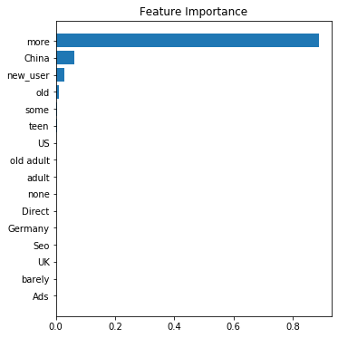

```python
feature_importance = boost.feature_importances_
sorted_idx = np.argsort(feature_importance)
pos = np.arange(sorted_idx.shape[0]) + .5
fig = plt.figure(figsize=(12, 6))
plt.subplot(1, 2, 1)
plt.barh(pos, feature_importance[sorted_idx], align='center')
plt.yticks(pos, np.array(X_train.columns)[sorted_idx])
plt.title('Feature Importance')

plt.show()
```

I suggest that the company should focus on Chinese market who tends to visit multiple web pages.